# Birdwatching CNN Classifier

## Introduction

`Birdwatching`, or birding, is a form of wildlife observation in which the observation of birds is a recreational activity or citizen science. It can be done with the naked eye, through a visual enhancement device like binoculars and telescopes, by listening for bird sounds,or by watching public webcams. Birdwatching often involves a significant auditory component, as many bird species are more easily detected and identified by ear than by eye. Most birdwatchers pursue this activity for recreational or social reasons, unlike ornithologists, who engage in the study of birds using formal scientific methods.

This project aims design a birdwatching App powered by a Deep CNN Netword. Using the App, the users are able to know the name of birds from their pictures.

```python
#import moodules
from matplotlib.pyplot import imshow
import numpy as np
import pandas as pd
import PIL
from PIL import Image
import tensorflow as tf
import keras
from keras import backend as K
from keras.preprocessing.image import ImageDataGenerator
import matplotlib.pyplot as plt
import seaborn as sns
import cv2
from glob import glob
from keras.preprocessing.image import load_img,img_to_array
from keras.utils import to_categorical
from keras.models import load_model, Model, Sequential
from keras.layers import Activation, Dense ,Dropout, Flatten , Conv2D, MaxPooling2D
from keras.layers import Flatten,Input, BatchNormalization, MaxPool2D
import os
```

## Dataset

The data we are using is from Kaggle. This dataset includes over 25,000 pictures from 140 kinds of birds. You could view or download source data [here](https://www.kaggle.com/gpiosenka/100-bird-species).  
**Note:** you will need a Kaggle account to view/download this dataset.

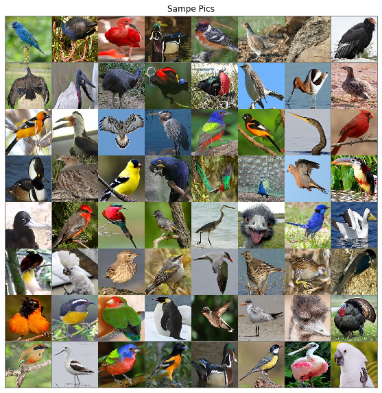

```python
#show some sample pictures
import sys
import time
import copy
import torch
import torch.nn.functional as F
from torch.optim import lr_scheduler
import torchvision
import torchvision.transforms as transforms

transform = transforms.Compose(
    [transforms.ToTensor(),
    transforms.Normalize((0.5, 0.5, 0.5), (0.5, 0.5, 0.5))]
)


trainset = torchvision.datasets.ImageFolder(root="C:/Users/Frank/PY Work/data/train/", transform=transform)
trainloader = torch.utils.data.DataLoader(trainset, batch_size=64, num_workers=0, shuffle=True)

testset = torchvision.datasets.ImageFolder(root="C:/Users/Frank/PY Work/data/test/", transform=transform)
testloader = torch.utils.data.DataLoader(testset, batch_size=64, num_workers=0, shuffle=False)

dataloaders = {
    "train": trainloader,
    "test": testloader
}
datasizes = {
    "train": len(trainset),
    "test": len(testset)
}

def imshow(img, size=(10, 10)):
    img = img / 2 + 0.5
    npimg = img.numpy()
    if size:
        plt.figure(figsize=size)

    plt.imshow(np.transpose(npimg, (1, 2, 0)))
    plt.title("Sampe Pics")
    plt.axis("off")
    plt.pause(0.001)
dataiter = iter(trainloader)
images, labels = dataiter.next()

imshow(torchvision.utils.make_grid(images))
```

Considering this dataset is too large, our group lacks funds to train this model in a powerful machine. Hence, this project will start from 6 birds.

```python
def read_images(path,num_img):
    array=np.zeros((num_img,224,224,3))
    i=0
    for img in os.listdir(path):
        img_path=path+"/"+img
        img=Image.open(img_path,mode="r")
        data=np.asarray(img,dtype="uint8")
        array[i]=data
        i+=1
    return array
#  TRAIN SECTION
train_albatros_path=r"C:/Users/Frank/PY Work/data/train/ALBATROSS"
num_train_albatros=len(glob("C:/Users/Frank/PY Work/data/train/ALBATROSS/*"))
train_albatros_array=read_images(train_albatros_path,num_train_albatros)

train_bald_eagle_path=r"C:/Users/Frank/PY Work/data/train/BALD EAGLE"
num_train_bald_eagle=len(glob("C:/Users/Frank/PY Work/data/train/BALD EAGLE/*"))
train_bald_eagle_array=read_images(train_albatros_path,num_train_bald_eagle)

train_american_goldfinch_path=r"C:/Users/Frank/PY Work/data/train/AMERICAN GOLDFINCH"
num_train_american_goldfinch=len(glob("C:/Users/Frank/PY Work/data/train/AMERICAN GOLDFINCH/*"))
train_american_goldfinch_array=read_images(train_american_goldfinch_path,num_train_american_goldfinch)

train_black_swan_path=r"C:/Users/Frank/PY Work/data/train/BLACK SWAN"
num_train_black_swan=len(glob("C:/Users/Frank/PY Work/data/train/BLACK SWAN/*"))
train_black_swan_array=read_images(train_black_swan_path,num_train_black_swan)

train_COCKATOO_path=r"C:/Users/Frank/PY Work/data/train/COCKATOO"
num_train_COCKATOO=len(glob("C:/Users/Frank/PY Work/data/train/COCKATOO/*"))
train_COCKATOO_array=read_images(train_COCKATOO_path,num_train_COCKATOO)

train_EMU_path=r"C:/Users/Frank/PY Work/data/train/EMU"
num_train_EMU=len(glob("C:/Users/Frank/PY Work/data/train/EMU/*"))
train_EMU_array=read_images(train_EMU_path,num_train_EMU)

#  VALIDATION SECTION
validation_albatros_path=r"C:/Users/Frank/PY Work/data/valid/ALBATROSS"
num_validation_albatros=len(glob("C:/Users/Frank/PY Work/data/valid/ALBATROSS/*"))
validation_albatros_array=read_images(validation_albatros_path,num_validation_albatros)

validation_bald_eagle_path=r"C:/Users/Frank/PY Work/data/valid/BALD EAGLE"
num_validation_bald_eagle=len(glob("C:/Users/Frank/PY Work/data/valid/BALD EAGLE/*"))
validation_bald_eagle_array=read_images(validation_bald_eagle_path,num_validation_bald_eagle)

validation_american_goldfinch_path=r"C:/Users/Frank/PY Work/data/valid/AMERICAN GOLDFINCH"
num_validation_american_goldfinch=len(glob("C:/Users/Frank/PY Work/data/valid/AMERICAN GOLDFINCH/*"))
validation_american_goldfinch_array=read_images(validation_american_goldfinch_path,num_validation_american_goldfinch)

validation_black_swan_path=r"C:/Users/Frank/PY Work/data/valid/BLACK SWAN"
num_validation_black_swan=len(glob("C:/Users/Frank/PY Work/data/valid/BLACK SWAN/*"))
validation_black_swan_array=read_images(validation_black_swan_path,num_validation_black_swan)

validation_COCKATOO_path=r"C:/Users/Frank/PY Work/data/valid/COCKATOO"
num_validation_COCKATOO=len(glob("C:/Users/Frank/PY Work/data/valid/COCKATOO/*"))
validation_COCKATOO_array=read_images(validation_COCKATOO_path,num_validation_COCKATOO)

validation_EMU_path=r"C:/Users/Frank/PY Work/data/valid/EMU"
num_validation_EMU=len(glob("C:/Users/Frank/PY Work/data/valid/EMU/*"))
validation_EMU_array=read_images(validation_EMU_path,num_validation_EMU)
```

```python
print("train albatros shape =",train_albatros_array.shape)
print("train bald eagle shape =",train_bald_eagle_array.shape)
print("train american goldfinch shape =",train_american_goldfinch_array.shape)
print("train black sawn =",train_black_swan_array.shape)
print("train COCKATOO shape =",train_COCKATOO_array.shape)
print("train EMU shape =",train_EMU_array.shape)

print("validation albatros shape =",validation_albatros_array.shape)
print("validation bald eagle shape =",validation_bald_eagle_array.shape)
print("validation american goldfinch shape =",validation_american_goldfinch_array.shape)
print("validation black sawn =",validation_black_swan_array.shape)
print("validation COCKATOO shape =",validation_COCKATOO_array.shape)
print("validation EMU shape =",validation_EMU_array.shape)
```

```
train albatros shape = (100, 224, 224, 3)
train bald eagle shape = (162, 224, 224, 3)
train american goldfinch shape = (134, 224, 224, 3)
train black sawn = (113, 224, 224, 3)
train COCKATOO shape = (166, 224, 224, 3)
train EMU shape = (106, 224, 224, 3)
validation albatros shape = (5, 224, 224, 3)
validation bald eagle shape = (5, 224, 224, 3)
validation american goldfinch shape = (5, 224, 224, 3)
validation black sawn = (5, 224, 224, 3)
validation COCKATOO shape = (5, 224, 224, 3)
validation EMU shape = (5, 224, 224, 3)
```

```python
#create validation set
x_train = np.concatenate((
    train_albatros_array,
    train_bald_eagle_array,
    train_american_goldfinch_array,
    train_black_swan_array,
    train_COCKATOO_array,
    train_EMU_array),axis=0)

x_val = np.concatenate((
    validation_albatros_array,
    validation_bald_eagle_array,
    validation_american_goldfinch_array,
    validation_black_swan_array,
    validation_COCKATOO_array,
    validation_EMU_array),axis=0)

print("x_train shape =",x_train.shape)
print("x_val shape =",x_val.shape)
```

```
x_train shape = (781, 224, 224, 3)
x_val shape = (30, 224, 224, 3)
```

```python
#resize pics
def resize_images(img):
    array=np.zeros((img.shape[0],100,100,3))
    for i in range(img.shape[0]):
        array[i] = cv2.resize(img[i,:,:,:],(100,100))
    return array
x_train=resize_images(x_train)
x_val=resize_images(x_val)
print("new x train shape :",x_train.shape)
print("new x validation shape :",x_val.shape)
```

```
new x train shape : (781, 100, 100, 3)
new x validation shape : (30, 100, 100, 3)
```

```python
#create some labels
y_train=np.concatenate((
    np.zeros(100),
    np.ones(162),
    np.full(134,2),
    np.full(113,3),
    np.full(166,4),
    np.full(106,5)),axis=0)

y_val=np.concatenate((
    np.zeros(5),
    np.ones(5),
    np.full(5,2),
    np.full(5,3),
    np.full(5,4),
    np.full(5,5)),axis=0)
print("y_train shape =",y_train.shape)
print("y_val shape =",y_val.shape)
```

```
y_train shape = (781,)
y_val shape = (30,)
```

```python
#categorize the output from 1-6
y_train = to_categorical(y_train,6)
y_val = to_categorical(y_val,6)
print("y_train shape =",y_train.shape)
print("y_val shape =",y_val.shape)
```

```
y_train shape = (781, 6)
y_val shape = (30, 6)
```

```python
#normalize
x_train=x_train / 255.0
x_val=x_val / 255.0
```

## Build a baseline CNN model

```python
baseline_model=Sequential()
baseline_model.add(Conv2D(20,(3,3),activation="relu",padding="same",input_shape=(100,100,3)))
baseline_model.add(Flatten())
baseline_model.add(Dense(206,activation="relu"))
baseline_model.add(Dense(103,activation="relu"))
baseline_model.add(Dense(6,activation="softmax"))
baseline_model.summary()
```

```
Model: "sequential_1"
_________________________________________________________________
Layer (type)                 Output Shape              Param #
=================================================================
conv2d_1 (Conv2D)            (None, 100, 100, 20)      560
_________________________________________________________________
flatten_1 (Flatten)          (None, 200000)            0
_________________________________________________________________
dense_1 (Dense)              (None, 206)               41200206
_________________________________________________________________
dense_2 (Dense)              (None, 103)               21321
_________________________________________________________________
dense_3 (Dense)              (None, 6)                 624
=================================================================
Total params: 41,222,711
Trainable params: 41,222,711
Non-trainable params: 0
_________________________________________________________________
```

```python
baseline_model.compile(optimizer="sgd",
              loss="categorical_crossentropy",
              metrics=["categorical_accuracy"])

history = baseline_model.fit(x_train,
                    y_train,
                    batch_size=250,
                    epochs = 100,
                    validation_data = (x_val,y_val))
```

```
Train on 781 samples, validate on 30 samples
```

```python
print(history.history.keys())
```

```
dict_keys(['val_loss', 'val_categorical_accuracy', 'loss', 'categorical_accuracy'])
```

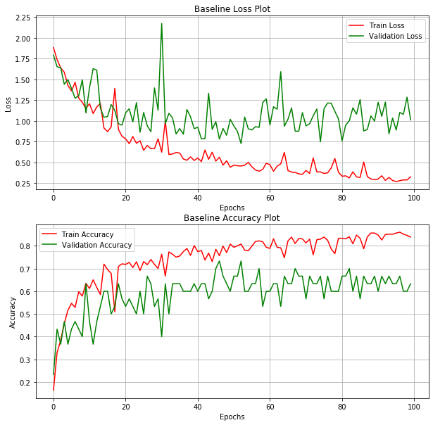

```python
plt.figure(figsize=(10,10))
plt.subplot(211)
plt.plot(history.history["loss"],color="red",label="Train Loss")
plt.plot(history.history["val_loss"],color="green",label="Validation Loss")
plt.legend()
plt.grid()
plt.title("Baseline Loss Plot")
plt.xlabel("Epochs")
plt.ylabel("Loss")

plt.subplot(212)
plt.plot(history.history["categorical_accuracy"],color="red",label="Train Accuracy")
plt.plot(history.history["val_categorical_accuracy"],color="green",label="Validation Accuracy")
plt.legend()
plt.grid()
plt.title("Baseline Accuracy Plot")
plt.xlabel("Epochs")
plt.ylabel("Accuracy")

plt.show()
```

Baseline model looks decent in training accuracy however shows overfitting issues as seeing large gap between training loss and val loss. To improve model, we will focus on reducing the overfitting issues.

## Improved Model

```python
#build CNN Model with more layers and dropouts
model=Sequential()
model.add(Conv2D(20,(3,3),activation="relu",padding="same",input_shape=(100,100,3)))
model.add(MaxPooling2D())
model.add(Dropout(0.25))
model.add(Flatten())
model.add(Dense(206,activation="relu"))
model.add(Dropout(0.25))
model.add(Dense(103,activation="relu"))
model.add(Dropout(0.25))
model.add(Dense(6,activation="softmax"))
model.summary()
```

```
Model: "sequential_3"
_________________________________________________________________
Layer (type)                 Output Shape              Param #
=================================================================
conv2d_3 (Conv2D)            (None, 100, 100, 20)      560
_________________________________________________________________
max_pooling2d_2 (MaxPooling2 (None, 50, 50, 20)        0
_________________________________________________________________
dropout_4 (Dropout)          (None, 50, 50, 20)        0
_________________________________________________________________
flatten_3 (Flatten)          (None, 50000)             0
_________________________________________________________________
dense_7 (Dense)              (None, 206)               10300206
_________________________________________________________________
dropout_5 (Dropout)          (None, 206)               0
_________________________________________________________________
dense_8 (Dense)              (None, 103)               21321
_________________________________________________________________
dropout_6 (Dropout)          (None, 103)               0
_________________________________________________________________
dense_9 (Dense)              (None, 6)                 624
=================================================================
Total params: 10,322,711
Trainable params: 10,322,711
Non-trainable params: 0
_________________________________________________________________
```

```python
#choose adam as optimizer
model.compile(optimizer="adam",
              loss="categorical_crossentropy",
              metrics=["categorical_accuracy"])

# adding early stops
callback = tf.keras.callbacks.EarlyStopping(monitor='val_loss', patience=4)


history = model.fit(x_train,
                    y_train,
                    batch_size=250,
                    epochs = 100,
                    validation_data = (x_val,y_val),
                    callbacks=[callback])
```

```
Train on 781 samples, validate on 30 samples
```

```python
print(history.history.keys())
```

```
dict_keys(['val_loss', 'val_categorical_accuracy', 'loss', 'categorical_accuracy'])
```

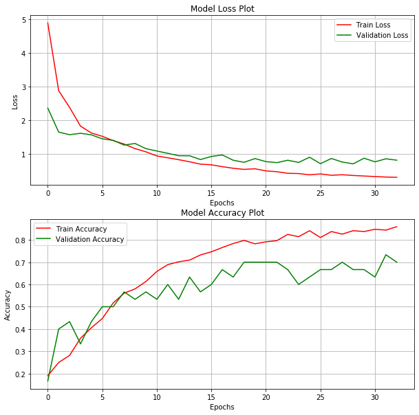

```python
plt.figure(figsize=(10,10))
plt.subplot(211)
plt.plot(history.history["loss"],color="red",label="Train Loss")
plt.plot(history.history["val_loss"],color="green",label="Validation Loss")
plt.legend()
plt.grid()
plt.title("Model Loss Plot")
plt.xlabel("Epochs")
plt.ylabel("Loss")

plt.subplot(212)
plt.plot(history.history["categorical_accuracy"],color="red",label="Train Accuracy")
plt.plot(history.history["val_categorical_accuracy"],color="green",label="Validation Accuracy")
plt.legend()
plt.grid()
plt.title("Model Accuracy Plot")
plt.xlabel("Epochs")
plt.ylabel("Accuracy")

plt.show()
```

## Conclusion

This model also has dencent accuracy score and also controls overfitting problems beter than the baseline model. Furthermore, adding early stop was able to reducing time a lot.